# Practical Machine Learning Final Course - Prediction of the Manner of Doing Exercise of Training Participants

Joao A. Silva

June 25, 2016

## **Background and Project Goal**

Using devices such as Jawbone Up, Nike FuelBand, and Fitbit it is now possible to collect a large amount of data about personal activity relatively inexpensively. These type of devices are part of the quantified self movement - a group of enthusiasts who take measurements about themselves regularly to improve their health, to find patterns in their behavior, or because they are tech geeks. One thing that people regularly do is quantify how much of a particular activity they do, but they rarely quantify how well they do it. In this project, your goal will be to use data from accelerometers on the belt, forearm, arm, and dumbell of 6 participants. They were asked to perform barbell lifts correctly and incorrectly in 5 different ways. More information is available from the website here: http://groupware.les.inf.puc-rio.br/har (see the section on the Weight Lifting Exercise Dataset).

So, the goal of this project is to predict the manner in which they did the exercise. This is the “classe” variable in the training set. So, I will describe how the model is built, how to cross validates it, evaluate the expected out of sample error, and explain the rationales of any choice made. The prediction model will be used to predict 20 different test cases.

## **Data and Exploratory Analisys**

### Data Overview

The training data for this project are available at https://d396qusza40orc.cloudfront.net/predmachlearn/pml-training.csv and the test data are available at https://d396qusza40orc.cloudfront.net/predmachlearn/pml-testing.csv

A short description of the dataset content from the authors’ website: “*Six young health participants were asked to perform one set of 10 repetitions of the Unilateral Dumbbell Biceps Curl in five different fashions: exactly according to the specification (Class A), throwing the elbows to the front (Class B), lifting the dumbbell only halfway (Class C), lowering the dumbbell only halfway (Class D) and throwing the hips to the front (Class E)*”.

### Enviroment Setup

Upload the R libraries that are necessary for complete analysis.

```r
library(knitr)
library(caret)
```

```r
library(rpart)
library(rpart.plot)
library(rattle)
library(randomForest)
library(corrplot)
set.seed(123)
```

### Data Loanding and Cleaning

In this step the dataset is loading from the URL provided above. Then, the training dataset is divided in 2, in order to create a Training set (70% of the data) for the modeling process and a Test set (30% remaining) for the validations. The testing dataset will only be used for the quiz results generation, so it is not changed at all.

#### Loading the Data

```r
# urls for the download
train <- "http://d396qusza40orc.cloudfront.net/predmachlearn/pml-training.csv"
test  <- "http://d396qusza40orc.cloudfront.net/predmachlearn/pml-testing.csv"

# download the datasets
dataTraining <- read.csv(url(train))
dataTesting  <- read.csv(url(test))

dim(dataTraining)
```

```
## [1] 19622   160
```

```r
dim(dataTesting)
```

```
## [1]  20 160
```

#### Cleaning the Data

```r
# remove columns with the most NAs values
isNA <- colSums(is.na(dataTraining)) == 0
dataTraining <- dataTraining[, isNA]
dataTesting <- dataTesting[, isNA]

# remove the descriptive columns
dataTraining <- dataTraining[,-c(1,5)]
dataTesting <- dataTesting[,-c(1,5)]

# remove variables with Nearly Zero Variance
zeroVar<- nearZeroVar(dataTraining)
dataTraining <- dataTraining[, -zeroVar]
dataTesting  <- dataTesting[, -zeroVar]

dim(dataTraining)
```

```
## [1] 19622    57
```

```r
dim(dataTesting)
```

```
## [1] 20 57
```

### Spliting the Training Dataset

The training dataset is then partinioned in 2, in order to create a training set with 70% of the data. This 70% of the data will be used for the modeling process and the remaining 30% of the data will be used for the validations. Since the testing dataset will only used for the quiz results, then it is not changed at all.

```r
inTrain  <- createDataPartition(dataTraining$classe, p=0.7, list=FALSE)
trainSet <- dataTraining[inTrain, ]
valSet  <- dataTraining[-inTrain, ]
```

### Correlation Analisys

Before proceeding to the modeling procedures, a correlation among variables is done. The highly correlated variables are shown in dark colors in the graph bellow.

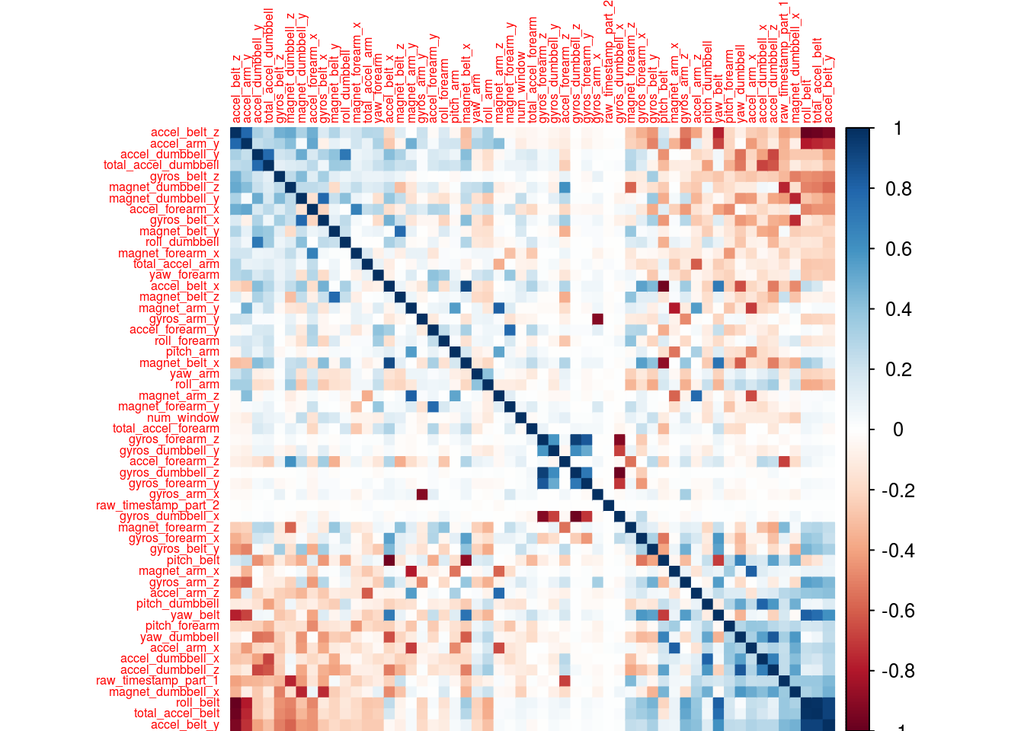

```r
trainDataNum <- dataTraining[, sapply(dataTraining, is.numeric)]
corrplot(cor(trainDataNum[, -57]), order = "FPC", method = "color", tl.cex = 0.5)
```

## **Prediction Model Building**

In order to perform the analisys, two methods will be applied to model the regressions (in the Train dataset).The model with higher accuracy when applied to the validate dataset will be used for the quiz predictions. The methods are: Decision Tree and Random Forests, as described below. A Confusion Matrix is presented to better visualize the accuracy of the models.

**a) Method:Decision Tree**

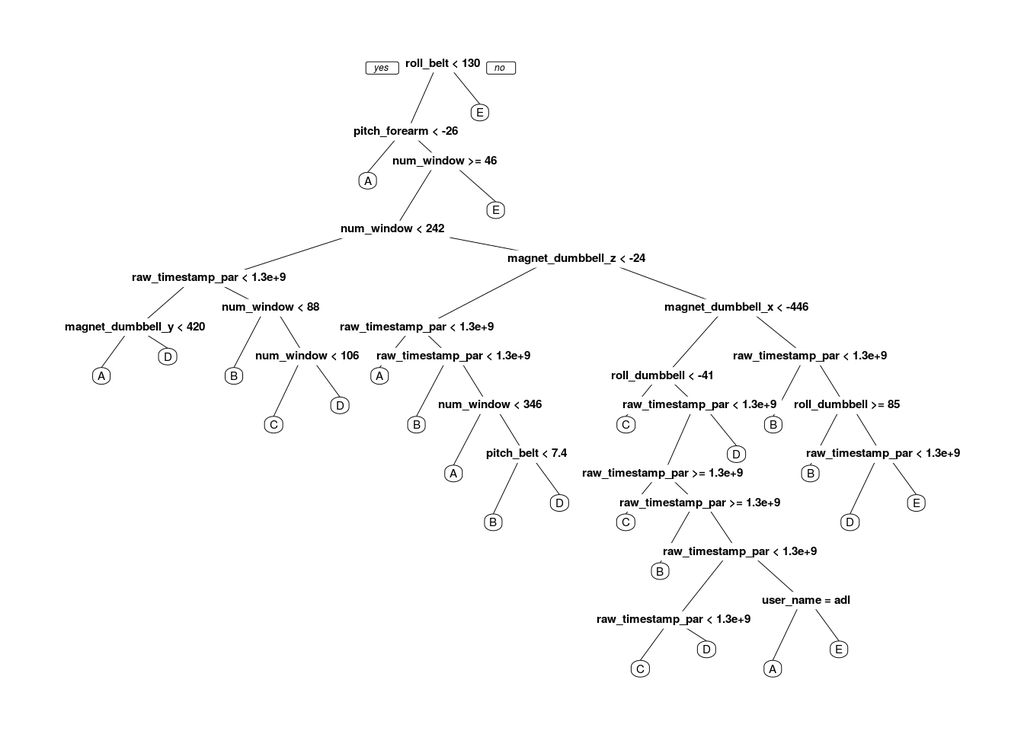

```r
# model fit
fitDecTree <- rpart(classe ~ ., data=trainSet, method="class")
prp(fitDecTree)
```

```r
# prediction on Test dataset
predict <- predict(fitDecTree, newdata=valSet, type="class")
confMatrix <- confusionMatrix(predict, valSet$classe)
confMatrix
```

```
## Confusion Matrix and Statistics
##
##           Reference
## Prediction    A    B    C    D    E
##          A 1542   51    3    0    6
##          B   40  899   23    8   33
##          C   29   96  906  122   31
##          D   56   69   82  749   73
##          E    7   24   12   85  939
##
## Overall Statistics
##
##                Accuracy : 0.8556
##                  95% CI : (0.8463, 0.8645)
##     No Information Rate : 0.2845
##     P-Value [Acc > NIR] : < 2.2e-16
##
##                   Kappa : 0.8178
##  Mcnemar's Test P-Value : < 2.2e-16
##
## Statistics by Class:
##
##                      Class: A Class: B Class: C Class: D Class: E
## Sensitivity            0.9211   0.7893   0.8830   0.7770   0.8678
## Specificity            0.9858   0.9781   0.9428   0.9431   0.9733
## Pos Pred Value         0.9625   0.8963   0.7652   0.7279   0.8800
## Neg Pred Value         0.9692   0.9508   0.9745   0.9557   0.9703
## Prevalence             0.2845   0.1935   0.1743   0.1638   0.1839
## Detection Rate         0.2620   0.1528   0.1540   0.1273   0.1596
## Detection Prevalence   0.2722   0.1704   0.2012   0.1749   0.1813
## Balanced Accuracy      0.9534   0.8837   0.9129   0.8600   0.9206
```

**b) Method: Random Forest**

```r
#modelFit
fitRandForest <- train(classe ~ ., data=trainSet, method="rf")
fitRandForest$finalModel
```

```
##
## Call:
##  randomForest(x = x, y = y, mtry = param$mtry)
##                Type of random forest: classification
##                      Number of trees: 500
## No. of variables tried at each split: 31
##
##         OOB estimate of  error rate: 0.11%
## Confusion matrix:
##      A    B    C    D    E  class.error
## A 3906    0    0    0    0 0.0000000000
## B    2 2654    2    0    0 0.0015048909
## C    0    2 2394    0    0 0.0008347245
## D    0    0    7 2245    0 0.0031083481
## E    0    0    0    2 2523 0.0007920792
```

```r
# prediction on Validate dataset
predict<- predict(fitRandForest, newdata=valSet)
confMatrix <- confusionMatrix(predict, valSet$classe)
confMatrix
```

```
## Confusion Matrix and Statistics
##
##           Reference
## Prediction    A    B    C    D    E
##          A 1674    0    0    0    0
##          B    0 1139    3    0    0
##          C    0    0 1023    2    0
##          D    0    0    0  961    0
##          E    0    0    0    1 1082
##
## Overall Statistics
##
##                Accuracy : 0.999
##                  95% CI : (0.9978, 0.9996)
##     No Information Rate : 0.2845
##     P-Value [Acc > NIR] : < 2.2e-16
##
##                   Kappa : 0.9987
##  Mcnemar's Test P-Value : NA
##
## Statistics by Class:
##
##                      Class: A Class: B Class: C Class: D Class: E
## Sensitivity            1.0000   1.0000   0.9971   0.9969   1.0000
## Specificity            1.0000   0.9994   0.9996   1.0000   0.9998
## Pos Pred Value         1.0000   0.9974   0.9980   1.0000   0.9991
## Neg Pred Value         1.0000   1.0000   0.9994   0.9994   1.0000
## Prevalence             0.2845   0.1935   0.1743   0.1638   0.1839
## Detection Rate         0.2845   0.1935   0.1738   0.1633   0.1839
## Detection Prevalence   0.2845   0.1941   0.1742   0.1633   0.1840
## Balanced Accuracy      1.0000   0.9997   0.9983   0.9984   0.9999
```

## **Applying the Selected Model to the Test Data**

The Random Forest model is the best model and so it will be applied to predict the 20 quiz cases. The code for this is shown below.

```r
predict <- predict(fitRandForest, newdata=dataTesting)
predict
```

```
##  [1] B A B A A E D B A A B C B A E E A B B B
## Levels: A B C D E
```